```r
#TRATAMENTO DOS DADOS
documento <- read.csv("C:/Users/lucas.general/Documents/Documentos R Markdown/Governo_Aberto/Aquisicao_bens_e_serviços.csv", encoding = "UTF-8")

documento <- documento %>%
  rename(Data.da.Aquisicao = 'Data.da.Aquisição',
         descricao = 'Descrição.do.item.serviço.adquirido') %>%
  mutate(Data.da.Aquisicao2 = as.Date(as.character(Data.da.Aquisicao), '%d/%m/%Y'),
         year_month = format(Data.da.Aquisicao2, "%Y-%m"),
         ano = format(Data.da.Aquisicao2, "%Y"))

quarentena <- c("2020-03")
```

```r
casos <- read.csv("C:/Users/lucas.general/Documents/Documentos R Markdown/Governo_Aberto/Covid_SP.csv", encoding = "UTF-8")

casos <- casos %>%
  mutate(Data = as.Date(as.character(Data), '%d/%m/%Y'),
         year_month = format(Data, "%Y-%m"),
         ano = format(Data, "%Y")) %>%
  rename(obitos = 'Óbitos.por.dia')
```

```r
color_linhas <- c('1-Azul' = "#6699CC", '15-Prata' = "#CCCCCC", '2-Verde' ="#66CC66", '3-Vermelha' = "#FF3300")
```

# Análise Inicial do Impacto da Pandemia dentro do transporte público

O documento tem como objetivo entender riscos que parte da população de São Paulo teve que assumir para se locomover na pandemia através do transporte público da cidade, mais especificamente o metrô. Foram considerados 2 escopos para calcular esse risco:

- Riscos de se estar em um ambiente pouco arejado, através de:
  - Infraestrutura oferecida pelo transporte público (quantidade e intervalo entre os trens)
  - Quantidade de pessoas por metro quadrado dentro do metrô
- Investimento do governo para prevenção de Covid dentro do transporte

De Março até Maio de 2020 - A Linha 15-Prata permaneceu fechada devido à inspeção da frota de trens motivada pelo rompimento de um pneu de uma composição.

## Riscos

https://www.bbc.com/portuguese/geral-54442075

Para o cálculo de risco foi considerado uma tabela formulado por pesquisadores da Universidade de Oxford em conjunto com o Instituto de Tecnologia de Massachusets (MIT). A tabela é:

[figure not shown]

```r
knitr::include_graphics("Imagens/Riscos_Covid.png")
```

O documento prevê distância segura de 2m entre pessoas. O estudo não especifica o que é um tempo longo ou curto, por isso nos basearemos em indicações de alguns órgãos de saúde que consideram até 15 minutos um tempo curto e mais que isso um tempo longo.

### Infraestrutura Oferecida

Houve um aumento no intervalo dos trens pós primeiro lockdown. As linhas vermelha e azul voltaram ao mesmo intervalo pré lockdown em Julho de 2020, a linha verde se estabilizou com intervalo maior do que antes da pandemia. Não temos dados suficientes da linha Prata.

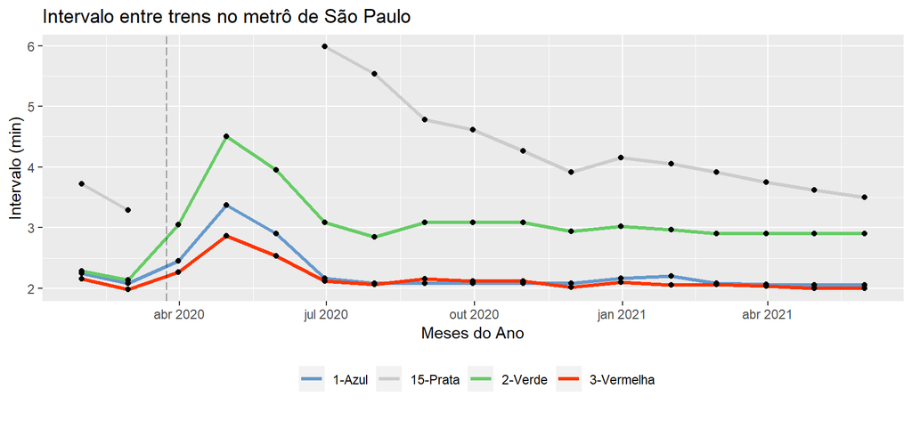

```r
quarentena2 <- c("2020-03-24")

infraestrutura <- read.csv("C:/Users/lucas.general/Documents/Documentos R Markdown/Governo_Aberto/Infraestrutura.csv", encoding = "UTF-8")

infraestrutura <- infraestrutura %>%
  mutate(periodo = as.Date(as.character(periodo), '%d/%m/%Y'))


infraestrutura %>%
  ggplot() +
  geom_line(aes(x=periodo, y=intervalo/60, group = linha, color= linha), size = 1.2)+
  geom_point(aes(x=periodo, y=intervalo/60, group = linha), size = 1.5)+
  geom_vline(xintercept = as.Date(quarentena2), lty = 5, alpha = 0.4)+
  labs(title = "Intervalo entre trens no metrô de São Paulo",
       x = "Meses do Ano",
       y = "Intervalo (min)",
       color = "",
       caption = "")+
  theme(legend.position="bottom") +
  scale_color_manual(values=color_linhas)
```

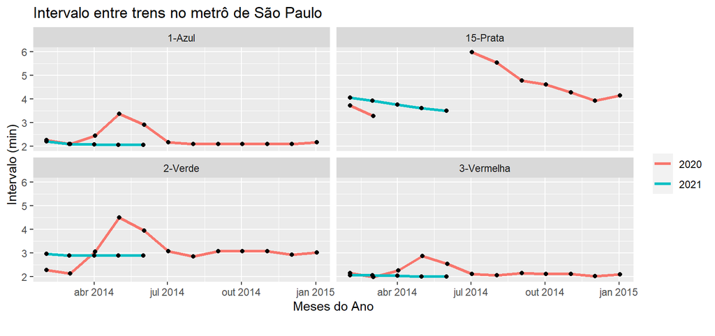

```r
infraestrutura %>%
  mutate(ano = format(periodo, '%Y'),
         dia = lubridate::yday(periodo),
         dias2 = as.Date(dia, origin = "2014-01-01")) %>%
  ggplot() +
  geom_line(aes(x=dias2, y=intervalo/60, group = ano, color= ano), size = 1.2)+
  geom_point(aes(x=dias2, y=intervalo/60, group = linha), size = 1.5)+
  facet_wrap(. ~ linha, nrow = 2) +
  labs(title = "Intervalo entre trens no metrô de São Paulo",
       x = "Meses do Ano",
       y = "Intervalo (min)",
       color = "",
       caption = "")
```

Houve um pequeno aumento na velocidade comercial das linhas Azul e Vermelha. Não houve mudanças na quantidade de carros dispostos em todas as linhas.

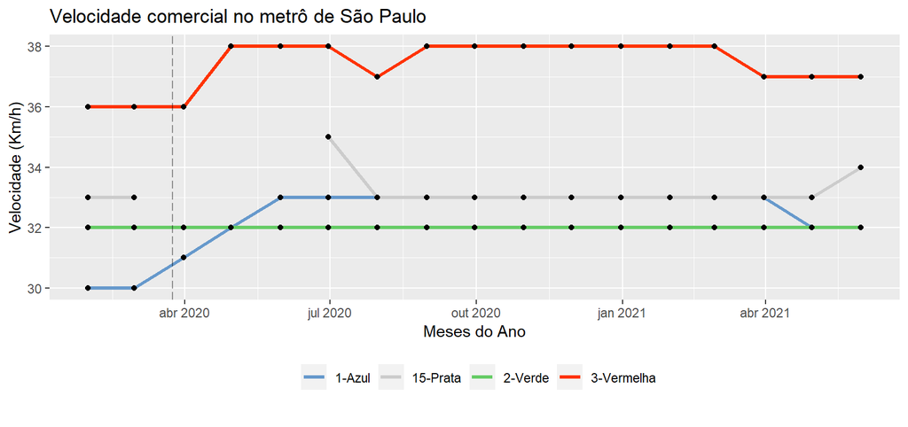

```r
infraestrutura %>%
  ggplot() +
  geom_line(aes(x=periodo, y=velocidade_comercial, group = linha, color= linha), size = 1.2)+
  geom_point(aes(x=periodo, y=velocidade_comercial, group = linha), size = 1.5)+
  geom_vline(xintercept = as.Date(quarentena2), lty = 5, alpha = 0.4)+
  labs(title = "Velocidade comercial no metrô de São Paulo",
       x = "Meses do Ano",
       y = "Velocidade (Km/h)",
       color = "",
       caption = "")+
  theme(legend.position="bottom")+
  scale_color_manual(values=color_linhas)
```

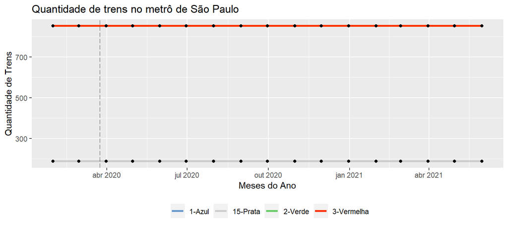

```r
infraestrutura %>%
  ggplot() +
  geom_line(aes(x=periodo, y=carros, group = linha, color= linha), size = 1.2)+
  geom_point(aes(x=periodo, y=carros, group = linha), size = 1.5)+
  geom_vline(xintercept = as.Date(quarentena2), lty = 5, alpha = 0.4)+
  labs(title = "Quantidade de trens no metrô de São Paulo",
       x = "Meses do Ano",
       y = "Quantidade de Trens",
       color = "",
       caption = "")+
  theme(legend.position="bottom")+
  scale_color_manual(values=color_linhas)
```

### Quantidade de usuários

Hoje temos cerca da metade do movimento diário que tinhamos no pico de utilização pré pandemia em todas as linhas.

```r
usuarios <- read.csv("C:/Users/lucas.general/Documents/Documentos R Markdown/Governo_Aberto/Demanda.csv", encoding = "UTF-8")

usuarios <- usuarios %>%
  mutate(periodo = as.Date(as.character(periodo), '%d/%m/%Y'))

datatable(usuarios %>%
  group_by(periodo, linha) %>%
  summarise(entradas = sum(entradas)) %>%
  mutate(mes = substring(periodo,1,7)) %>%
  select(mes, linha, entradas) %>%
  rename('Mês' = mes,
         Linha = linha,
         'Média passageiros dia (mil)' = entradas),
  caption = 'Passageiros por Mês')
```

|  | periodo | Mês | Linha | Média passageiros dia (mil) |
| --- | --- | --- | --- | --- |
| 1 | 2020-01-31 | 2020-01 | 1-Azul | 1216 |
| 2 | 2020-01-31 | 2020-01 | 15-Prata | 99 |
| 3 | 2020-01-31 | 2020-01 | 2-Verde | 702 |
| 4 | 2020-01-31 | 2020-01 | 3-Vermelha | 1213 |
| 5 | 2020-02-29 | 2020-02 | 1-Azul | 1410 |
| 6 | 2020-02-29 | 2020-02 | 15-Prata | 115 |
| 7 | 2020-02-29 | 2020-02 | 2-Verde | 826 |
| 8 | 2020-02-29 | 2020-02 | 3-Vermelha | 1381 |
| 9 | 2020-03-31 | 2020-03 | 1-Azul | 917 |
| 10 | 2020-03-31 | 2020-03 | 2-Verde | 515 |

[output cut: 55 more lines]

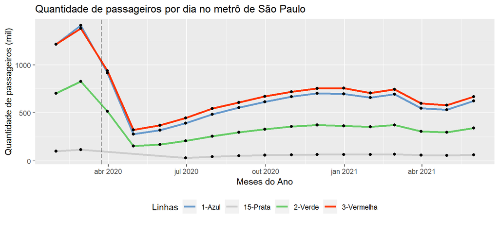

```r
usuarios %>%
  group_by(periodo, linha) %>%
  summarise(entradas = sum(entradas)) %>%
  ggplot() +
  geom_line(aes(x=periodo, y=entradas, group = linha, color= linha), size = 1.2)+
  geom_point(aes(x=periodo, y=entradas, group = linha), size = 1.5)+
  geom_vline(xintercept = as.Date(quarentena2), lty = 5, alpha = 0.4)+
  labs(title = "Quantidade de passageiros por dia no metrô de São Paulo",
       x = "Meses do Ano",
       y = "Quantidade de passageiros (mil)",
       color = "Linhas",
       caption = "")+
  theme(legend.position="bottom")+
  scale_color_manual(values=color_linhas)
```

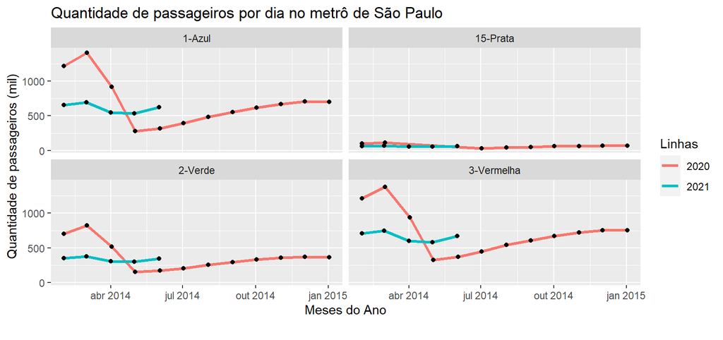

```r
usuarios %>%
  mutate(ano = format(periodo, '%Y'),
         dia = lubridate::yday(periodo),
         dias2 = as.Date(dia, origin = "2014-01-01")) %>%
  group_by(periodo, linha, dias2, ano) %>%
  summarise(entradas = sum(entradas)) %>%
  ggplot() +
  geom_line(aes(x=dias2, y=entradas, group = ano, color= ano), size = 1.2)+
  geom_point(aes(x=dias2, y=entradas, group = ano), size = 1.5)+
  facet_wrap(. ~ linha, nrow = 2) +
  labs(title = "Quantidade de passageiros por dia no metrô de São Paulo",
       x = "Meses do Ano",
       y = "Quantidade de passageiros (mil)",
       color = "Linhas",
       caption = "")
```

### Passageiros por metro quadrado

O ideal, para mantermos uma distância segura de 2m entre os passageiros, é que tenhamos 1 passageiro a cada 3.1 metros quadrados.

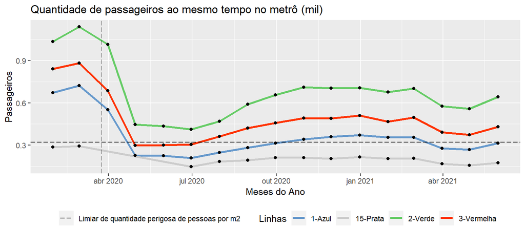

```r
carros <- usuarios %>%
  select(linha) %>%
  unique() %>%
  mutate(frota_disponivel_carros = ifelse(linha == '1-Azul', 240,
                                          ifelse(linha == '2-Verde', 150,
                                                 ifelse(linha == '3-Vermelha', 234,174
                                                        ))))
aux <- usuarios  %>%
  group_by(periodo, linha) %>%
  summarise(entradas = sum(entradas)*1000,
            estacoes = n()) %>%
  mutate(entradas_por_segundo = entradas/(71400*estacoes)) # quantidade de segundos que o metro fica On

aux <- aux %>%
  inner_join(infraestrutura %>%
               select(periodo, linha, intervalo),
             by = c('periodo' = 'periodo',
                   'linha' = 'linha')) %>%
  inner_join(carros, by = 'linha') %>%
  mutate(passageiros_por_trem = entradas_por_segundo*intervalo,
         passageiros_por_trem2 = passageiros_por_trem*10*60, # Tempo em segundos que o passageiro fica no trem
         passageiros_por_trem3 = passageiros_por_trem2/(frota_disponivel_carros*120*3.1) # Passageiros por metro quadradro
         )

aux %>%
  ggplot() +
  geom_line(aes(x=periodo, y=passageiros_por_trem3, group = linha, color= linha), size = 1.2)+
  geom_point(aes(x=periodo, y=passageiros_por_trem3, group = linha), size = 1.5)+
  geom_hline(aes(yintercept = 0.322, linetype = "Limiar de quantidade perigosa de pessoas por m2"))+
  geom_vline(xintercept = as.Date(quarentena2), lty = 5, alpha = 0.4)+
  scale_linetype_manual(name = "", values = c(5))+
  labs(title = "Quantidade de passageiros ao mesmo tempo no metrô (mil)",
       x = "Meses do Ano",
       y = "Passageiros",
       color = "Linhas",
       caption = "")+
  theme(legend.position="bottom")+
  scale_color_manual(values=color_linhas)
```

### Risco

Temos 4 possíveis situações aqui:

Infelizmente, boa parte dos usuários do metrô está no quarto contexto

## Investimentos do governo para prevenção de COVID em transportes públicos

### Ao longo do tempo

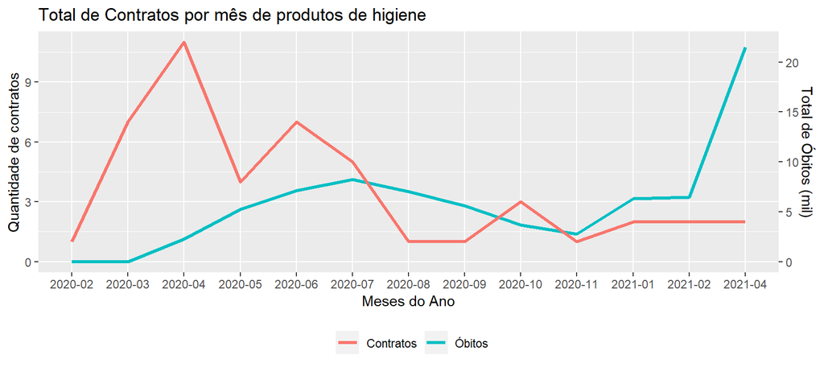

```r
aux <- documento %>%
  group_by(year_month, ano) %>%
  summarise(contratos = n(),
            valor_total = sum(Valor.Total)*1000) %>%
  inner_join(casos %>%
               group_by(year_month) %>%
               summarise(obitos = sum(obitos)),
             by = 'year_month')%>%
  mutate(obitos = ifelse(is.na(obitos), 0, obitos))

#documento %>%
#  colnames()

#documento %>%
#  select(Data.da.Aquisicao, Prazo.Contratual)

aux %>%
  ggplot() +
  geom_line(aes(x=year_month,y=obitos/2000, group = 1, color = 'Óbitos'),size = 1.2)+
  geom_line(aes(x=year_month,y=contratos, group = 1, color = 'Contratos'), size = 1.2)+
  scale_y_continuous(sec.axis = sec_axis(~.*2, name = "Total de Óbitos (mil)"))+
  #geom_vline(xintercept = quarentena, lty = 5, alpha = 0.4)+
  labs(title = "Total de Contratos por mês de produtos de higiene",
       #subtitle = "Share receita por BU",
       x = "Meses do Ano",
       y = "Quantidade de contratos",
       caption = "",
       color = "")+
  theme(legend.position="bottom")
```

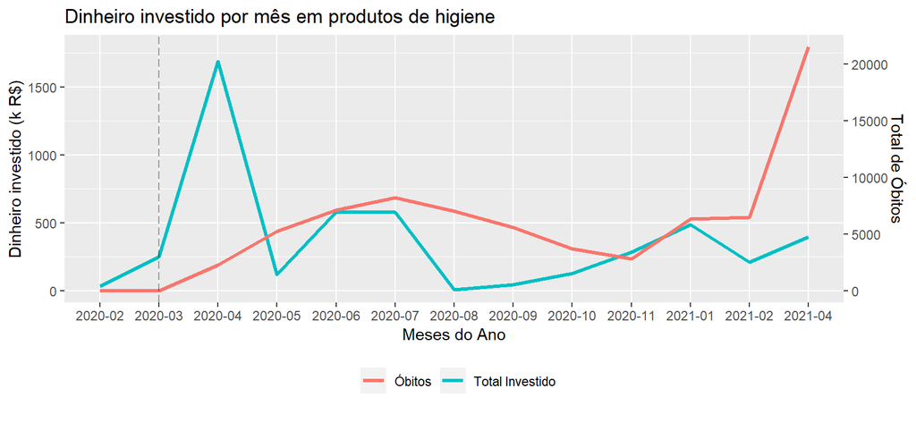

```r
aux %>%
  ggplot() +
  geom_line(aes(x=year_month,y=valor_total/1000, group = 1, color = 'Total Investido'), size = 1.2)+
  geom_line(aes(x=year_month,y=obitos/12, group = 1, color = 'Óbitos'), size = 1.2)+
  geom_vline(xintercept = quarentena, lty = 5, alpha = 0.4)+
  scale_y_continuous(sec.axis = sec_axis(~.*12, name = "Total de Óbitos"))+
  labs(title = "Dinheiro investido por mês em produtos de higiene",
       #subtitle = "Share receita por BU",
       x = "Meses do Ano",
       y = "Dinheiro investido (k R$)",
       color = "",
       caption = "")+
  theme(legend.position="bottom")
```

### O que foi comprado

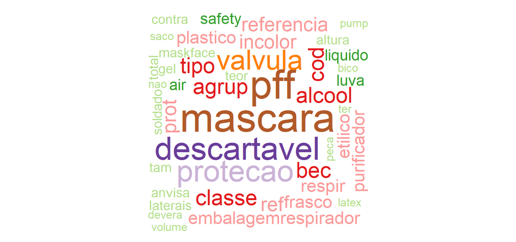

```r
reviews <- documento[10]
reviews <- reviews %>% drop_na()
reviews <- as.matrix(reviews)
reviews <- iconv(reviews,from="UTF-8",to="ASCII//TRANSLIT")

reviewsCorpus <- VCorpus(VectorSource(reviews))

reviewsCorpus <- tm_map(reviewsCorpus, removePunctuation)
reviewsCorpus <- tm_map(reviewsCorpus, content_transformer(tolower))
reviewsCorpus <- tm_map(reviewsCorpus, removeWords, c(stopwords("portuguese"),"com"))
#reviewsCorpus <- tm_map(reviewsCorpus, removeWords, c("com", "mascara"))

BigramTokenizer <- function(x) NGramTokenizer(x, Weka_control(min = 1, max = 3))

control_list = list(#tokenize = BigramTokenizer,
                    tokenize = "words",
                    removeNumbers = TRUE,
                    tolower = TRUE,
                    weighting = function(x)
                      weightTf(x)
)



reviewsDTM <- TermDocumentMatrix(reviewsCorpus,control_list)

reviewsDTM_tidy <- tidy(reviewsDTM)

df <- reviewsDTM_tidy %>%
  group_by(term) %>%
  summarise(freq = n()) %>% ## CONTO NUMERO DE TEXTOS QUE ELA APARECE
  arrange(desc(freq)) %>%  ## Se quiser contar número de aparições, muda de n() pra sum()
  rename('word' = 'term')

pal1 <- brewer.pal(12,"Paired")

WC <- wordcloud(df$word, df$freq, min.freq=3,
               max.words=Inf, random.order=FALSE,
               rot.per=.15,colors=pal1)
```

```r
total <- as.integer(reviews %>%
  as_tibble %>%
  count()-1)

df <- df %>%
  mutate(porcentagem = freq/total)

datatable(df %>%
  rename(contratos = freq),
  caption = 'Itens mais frequentes nos contratos') %>%
  formatPercentage (c("porcentagem"),  digits = 2)
```

|  | word | contratos | porcentagem |
| --- | --- | --- | --- |
| 1 | mascara | 17 | 0.369565217391304 |
| 2 | pff | 17 | 0.369565217391304 |
| 3 | descartavel | 13 | 0.282608695652174 |
| 4 | protecao | 12 | 0.260869565217391 |
| 5 | valvula | 11 | 0.239130434782609 |
| 6 | agrup | 8 | 0.173913043478261 |
| 7 | alcool | 8 | 0.173913043478261 |
| 8 | bec | 8 | 0.173913043478261 |
| 9 | classe | 8 | 0.173913043478261 |
| 10 | cod | 8 | 0.173913043478261 |

[output cut: 165 more lines]

#### 2020

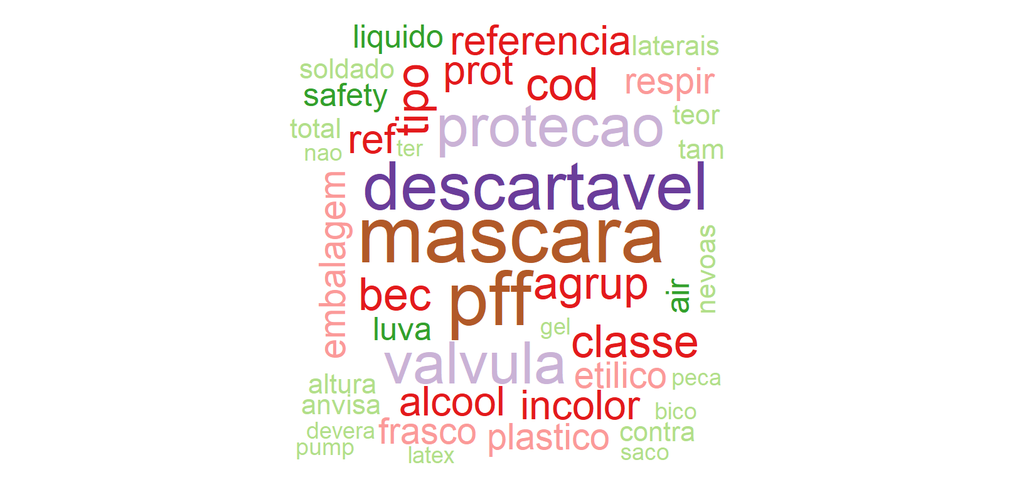

```r
reviews <- documento %>%
  filter(ano == 2020) %>%
  select(descricao)
reviews <- reviews %>% drop_na()
reviews <- as.matrix(reviews)
reviews <- iconv(reviews,from="UTF-8",to="ASCII//TRANSLIT")

reviewsCorpus <- VCorpus(VectorSource(reviews))

reviewsCorpus <- tm_map(reviewsCorpus, removePunctuation)
reviewsCorpus <- tm_map(reviewsCorpus, content_transformer(tolower))
reviewsCorpus <- tm_map(reviewsCorpus, removeWords, c(stopwords("portuguese"),"com"))
#reviewsCorpus <- tm_map(reviewsCorpus, removeWords, c("com", "mascara"))

BigramTokenizer <- function(x) NGramTokenizer(x, Weka_control(min = 1, max = 3))

control_list = list(#tokenize = BigramTokenizer,
                    tokenize = "words",
                    removeNumbers = TRUE,
                    tolower = TRUE,
                    weighting = function(x)
                      weightTf(x)
)



reviewsDTM <- TermDocumentMatrix(reviewsCorpus,control_list)

reviewsDTM_tidy <- tidy(reviewsDTM)

df <- reviewsDTM_tidy %>%
  group_by(term) %>%
  summarise(freq = n()) %>% ## CONTO NUMERO DE TEXTOS QUE ELA APARECE
  arrange(desc(freq)) %>%  ## Se quiser contar número de aparições, muda de n() pra sum()
  rename('word' = 'term')

pal1 <- brewer.pal(12,"Paired")

WC <- wordcloud(df$word, df$freq, min.freq=3,
               max.words=Inf, random.order=FALSE,
               rot.per=.15,colors=pal1)
```

```r
total <- as.integer(reviews %>%
  as_tibble %>%
  count()-1)

df <- df %>%
  mutate(porcentagem = freq/total)

datatable(df %>%
  rename(contratos = freq),
  caption = 'Itens mais frequentes nos contratos') %>%
  formatPercentage (c("porcentagem"),  digits = 2)
```

|  | word | contratos | porcentagem |
| --- | --- | --- | --- |
| 1 | mascara | 16 | 0.4 |
| 2 | pff | 15 | 0.375 |
| 3 | descartavel | 13 | 0.325 |
| 4 | protecao | 11 | 0.275 |
| 5 | valvula | 11 | 0.275 |
| 6 | agrup | 8 | 0.2 |
| 7 | bec | 8 | 0.2 |
| 8 | classe | 8 | 0.2 |
| 9 | cod | 8 | 0.2 |
| 10 | tipo | 8 | 0.2 |

[output cut: 165 more lines]

#### 2021

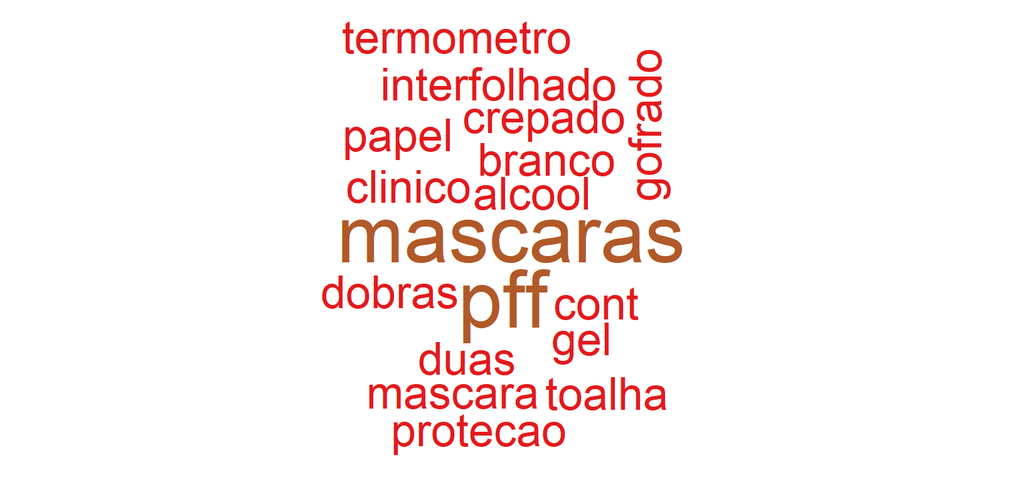

```r
reviews <- documento %>%
  filter(ano == 2021) %>%
  select(descricao)
reviews <- reviews %>% drop_na()
reviews <- as.matrix(reviews)
reviews <- iconv(reviews,from="UTF-8",to="ASCII//TRANSLIT")

reviewsCorpus <- VCorpus(VectorSource(reviews))

reviewsCorpus <- tm_map(reviewsCorpus, removePunctuation)
reviewsCorpus <- tm_map(reviewsCorpus, content_transformer(tolower))
reviewsCorpus <- tm_map(reviewsCorpus, removeWords, c(stopwords("portuguese"),"com"))
#reviewsCorpus <- tm_map(reviewsCorpus, removeWords, c("com", "mascara"))

BigramTokenizer <- function(x) NGramTokenizer(x, Weka_control(min = 1, max = 3))

control_list = list(#tokenize = BigramTokenizer,
                    tokenize = "words",
                    removeNumbers = TRUE,
                    tolower = TRUE,
                    weighting = function(x)
                      weightTf(x)
)



reviewsDTM <- TermDocumentMatrix(reviewsCorpus,control_list)

reviewsDTM_tidy <- tidy(reviewsDTM)

df <- reviewsDTM_tidy %>%
  group_by(term) %>%
  summarise(freq = n()) %>% ## CONTO NUMERO DE TEXTOS QUE ELA APARECE
  arrange(desc(freq)) %>%  ## Se quiser contar número de aparições, muda de n() pra sum()
  rename('word' = 'term')

pal1 <- brewer.pal(12,"Paired")

WC <- wordcloud(df$word, df$freq, min.freq=3,
               max.words=Inf, random.order=FALSE,
               rot.per=.15,colors=pal1)
```

```r
total <- as.integer(reviews %>%
  as_tibble %>%
  count()-1)

df <- df %>%
  mutate(porcentagem = freq/total)

datatable(df %>%
  rename(contratos = freq),
  caption = 'Itens mais frequentes nos contratos') %>%
  formatPercentage (c("porcentagem"),  digits = 2)
```

|  | word | contratos | porcentagem |
| --- | --- | --- | --- |
| 1 | mascaras | 2 | 0.4 |
| 2 | pff | 2 | 0.4 |
| 3 | alcool | 1 | 0.2 |
| 4 | branco | 1 | 0.2 |
| 5 | clinico | 1 | 0.2 |
| 6 | cont | 1 | 0.2 |
| 7 | crepado | 1 | 0.2 |
| 8 | dobras | 1 | 0.2 |
| 9 | duas | 1 | 0.2 |
| 10 | gel | 1 | 0.2 |

[output cut: 7 more lines]